# Desafio Intro ML - Curso-R

Ricardo Mattos

12/07/2020

# 1 Objetivo

O objetivo desse notebook é efetuar todo o processo de modelagem da base de dados `adult`, disponibilizada para o desafio do curso de introdução ao Machine Learning da Curso-R, utilizando o framework `tidymodels`. Ou seja, explorar, tratar, preparar, tunnar e escolher o modelo que melhor se ajusta aos dados disponibilizados.

O objetivo desse notebook é efetuar todo o processo de modelagem da base de dados `adult`, disponibilizada para o desafio do curso de introdução ao Machine Learning da Curso-R, utilizando o framework `tidymodels`. Ou seja, explorar, tratar, preparar, tunnar e escolher o modelo que melhor se ajusta aos dados disponibilizados. Vamos nessa!

# 2 Leitura da base

## 2.1 Informações preliminares

```r
adult <- read_rds("adult.rds")

# head(adult)

# glimpse(adult)
skim(adult)
```

Data summary

| Name | adult |
| --- | --- |
| Number of rows | 32561 |
| Number of columns | 16 |
| _______________________ |  |
| Column type frequency: |  |
| character | 9 |
| numeric | 7 |
| ________________________ |  |
| Group variables | None |

**Variable type: character**

| skim_variable | n_missing | complete_rate | min | max | empty | n_unique | whitespace |
| --- | --- | --- | --- | --- | --- | --- | --- |
| workclass | 1836 | 0.94 | 7 | 16 | 0 | 8 | 0 |
| education | 0 | 1.00 | 3 | 12 | 0 | 16 | 0 |
| marital_status | 0 | 1.00 | 7 | 21 | 0 | 7 | 0 |
| occupation | 1843 | 0.94 | 5 | 17 | 0 | 14 | 0 |
| relationship | 0 | 1.00 | 4 | 14 | 0 | 6 | 0 |
| race | 0 | 1.00 | 5 | 18 | 0 | 5 | 0 |
| sex | 0 | 1.00 | 4 | 6 | 0 | 2 | 0 |
| native_country | 583 | 0.98 | 4 | 26 | 0 | 41 | 0 |
| resposta | 0 | 1.00 | 4 | 5 | 0 | 2 | 0 |

**Variable type: numeric**

| skim_variable | n_missing | complete_rate | mean | sd | p0 | p25 | p50 | p75 | p100 | hist |
| --- | --- | --- | --- | --- | --- | --- | --- | --- | --- | --- |
| age | 0 | 1 | 38.58 | 13.64 | 17 | 28 | 37 | 48 | 90 | ▇▇▅▂▁ |
| fnlwgt | 0 | 1 | 189778.37 | 105549.98 | 12285 | 117827 | 178356 | 237051 | 1484705 | ▇▁▁▁▁ |
| education_num | 0 | 1 | 10.08 | 2.57 | 1 | 9 | 10 | 12 | 16 | ▁▁▇▃▁ |
| capital_gain | 0 | 1 | 1077.65 | 7385.29 | 0 | 0 | 0 | 0 | 99999 | ▇▁▁▁▁ |
| capital_loss | 0 | 1 | 87.30 | 402.96 | 0 | 0 | 0 | 0 | 4356 | ▇▁▁▁▁ |
| hours_per_week | 0 | 1 | 40.44 | 12.35 | 1 | 40 | 40 | 45 | 99 | ▁▇▃▁▁ |
| id | 0 | 1 | 16281.00 | 9399.70 | 1 | 8141 | 16281 | 24421 | 32561 | ▇▇▇▇▇ |

As variáveis parecem estar com formatos corretos. Ponto de atenção para as variáveis `wokclass`, `occupation` e `native_country`, que apresentam valores missing.

# 3 AED

Agora vamos analisar o comportamento das variáveis para definirmos como tratar os nossos dados para o modelo.

## 3.1 Parte 1

```r
# DataExplorer::create_report(adult)

devtools::source_url("https://raw.githubusercontent.com/ricardomattos05/functions/master/function_AED_bivariada.R")
#
#
adult2 <- adult %>%
            select(-id) %>%
            mutate(resposta = if_else(resposta == ">50K", 1, 0))
#
#

# names(adult2)
for (i in 1:(length(adult2)-1) ) {

  df <- adult2[,c(i,15)]
  cat("### ",names(df[,1]),"\n")
  print(AED_biv(df,glue("resposta"),"Pre"))
  cat('\n\n')
}
```

### 3.1.1 age

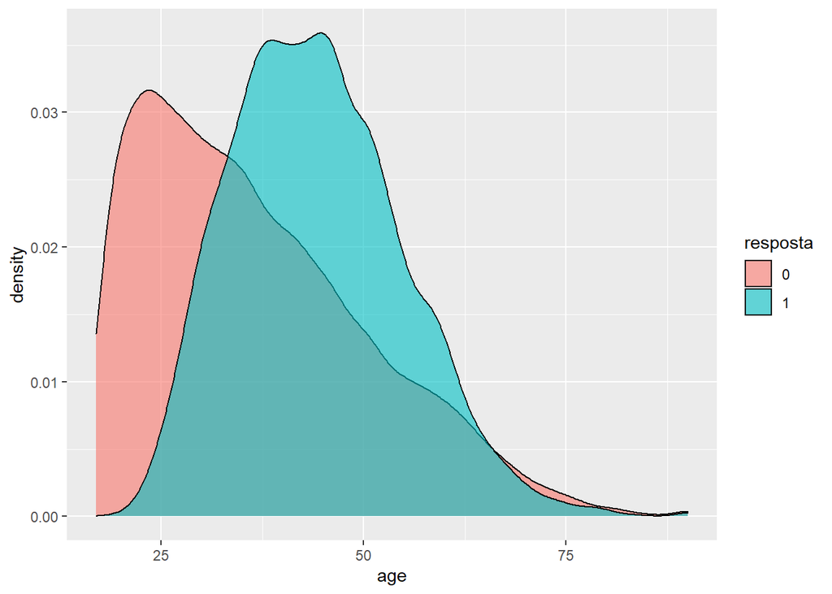

NULL

### 3.1.2 workclass

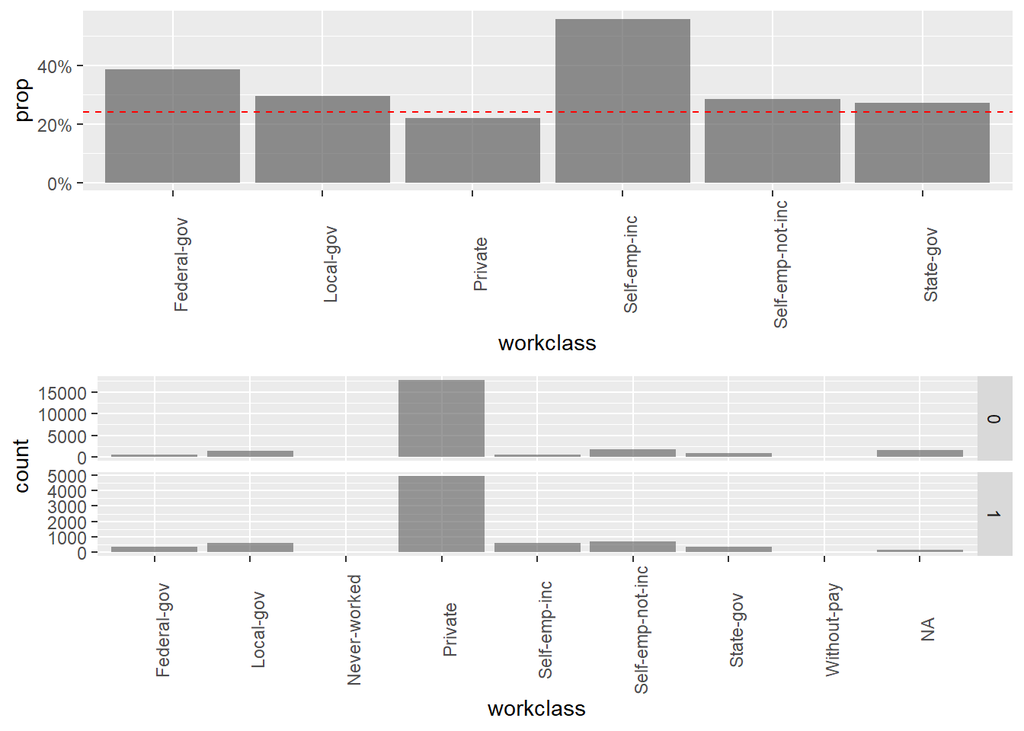

NULL

### 3.1.3 fnlwgt

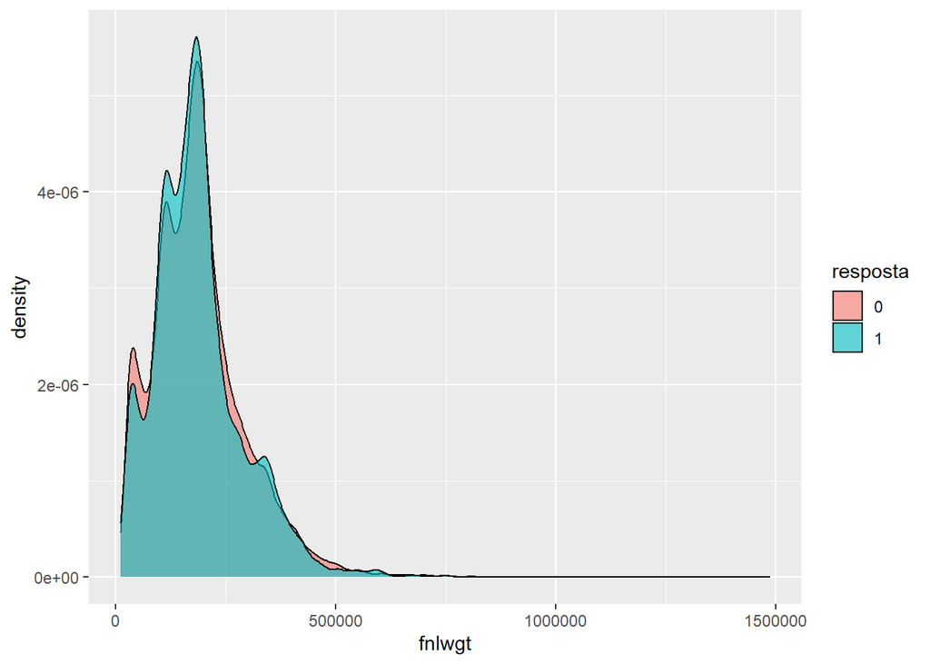

NULL

### 3.1.4 education

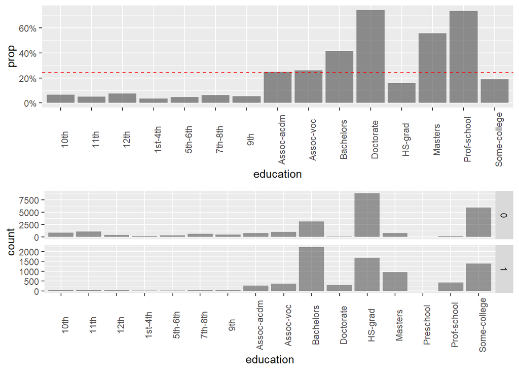

NULL

### 3.1.5 education_num

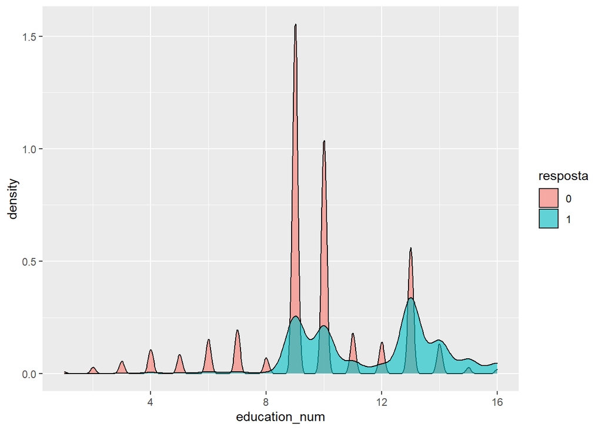

NULL

### 3.1.6 marital_status

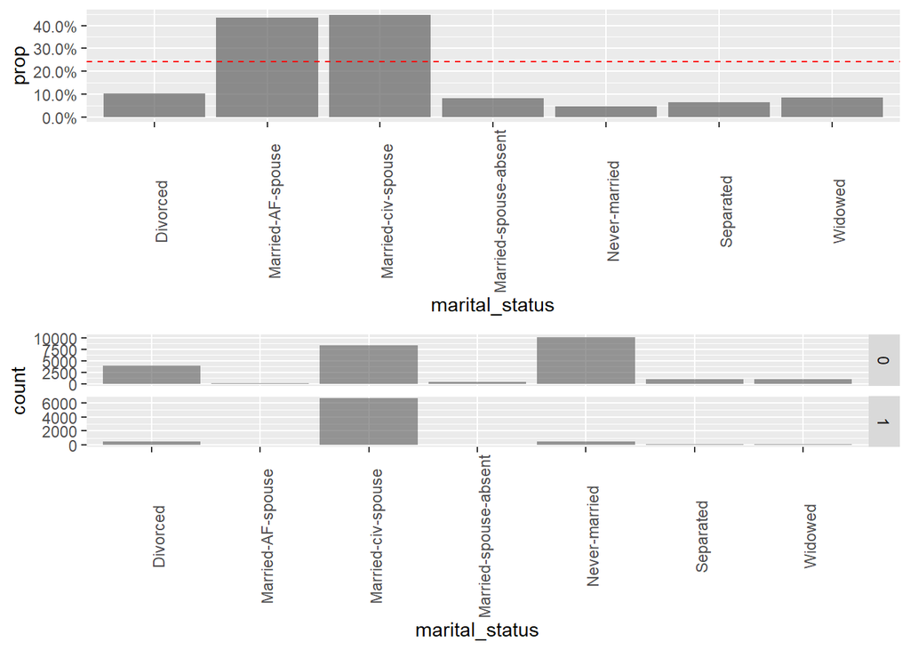

NULL

### 3.1.7 occupation

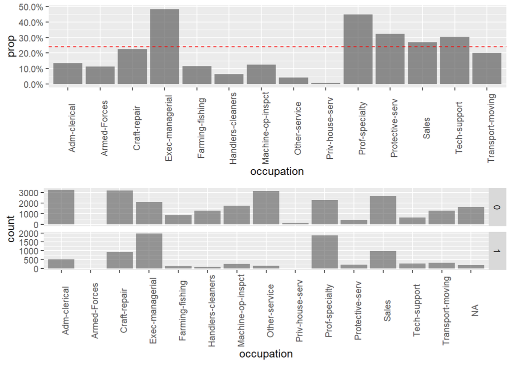

NULL

### 3.1.8 relationship

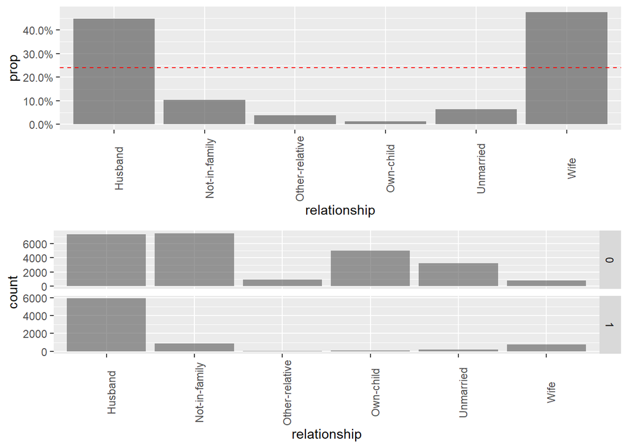

NULL

### 3.1.9 race

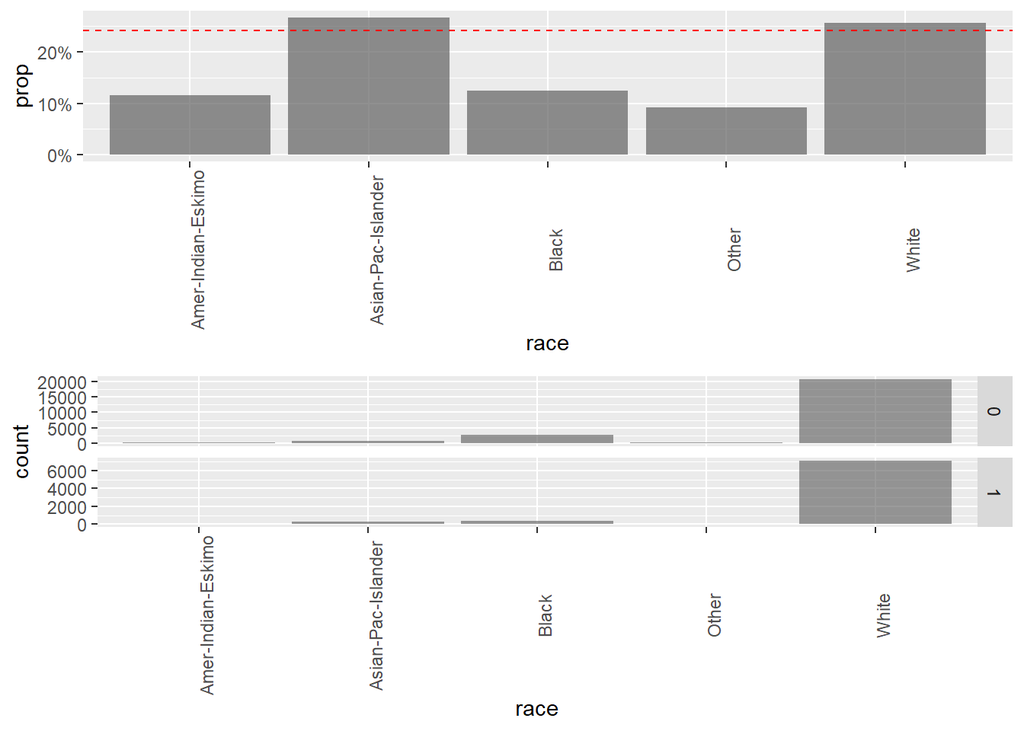

NULL

### 3.1.10 sex

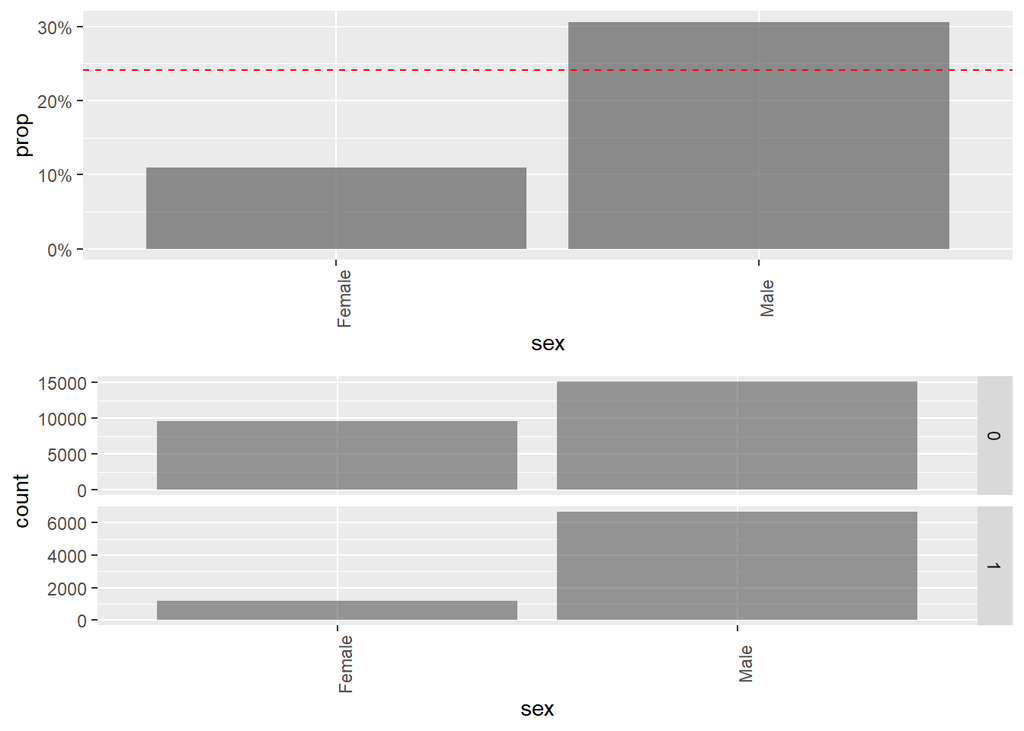

NULL

### 3.1.11 capital_gain

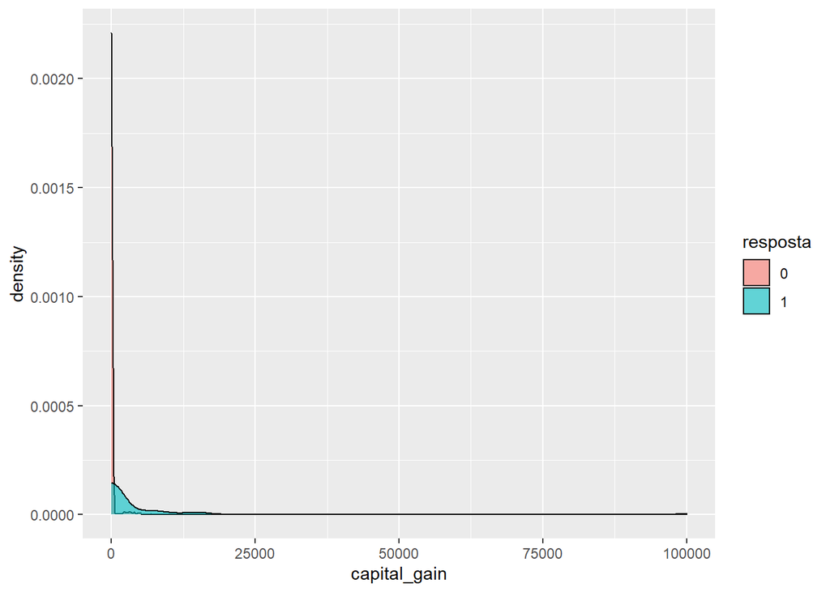

NULL

### 3.1.12 capital_loss

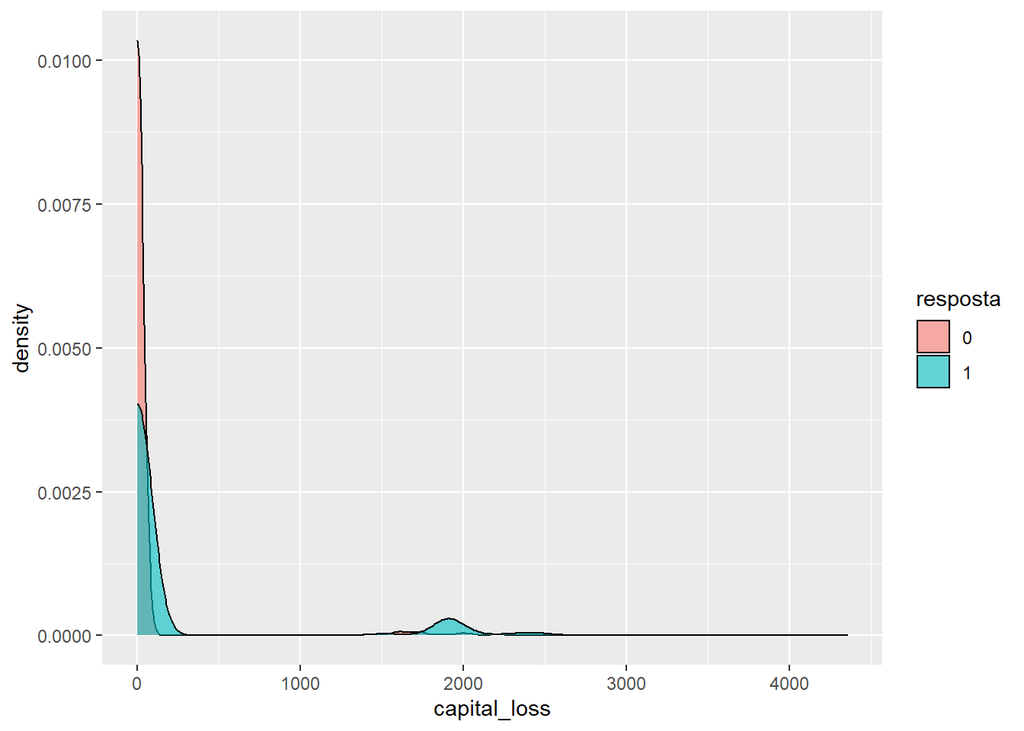

NULL

### 3.1.13 hours_per_week

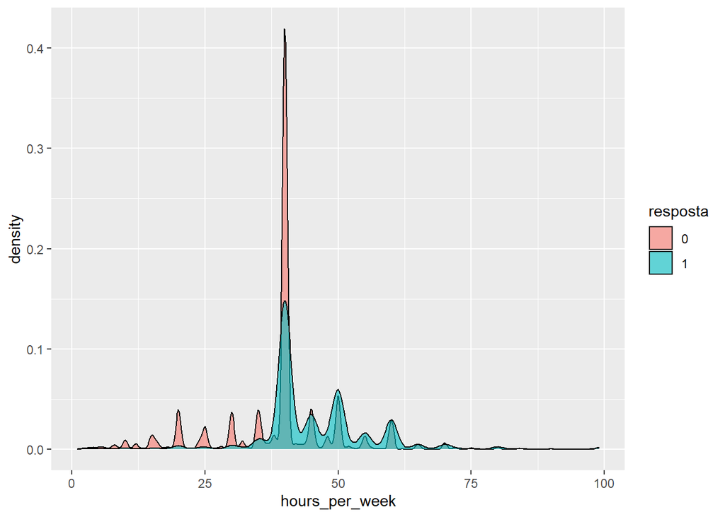

NULL

### 3.1.14 native_country

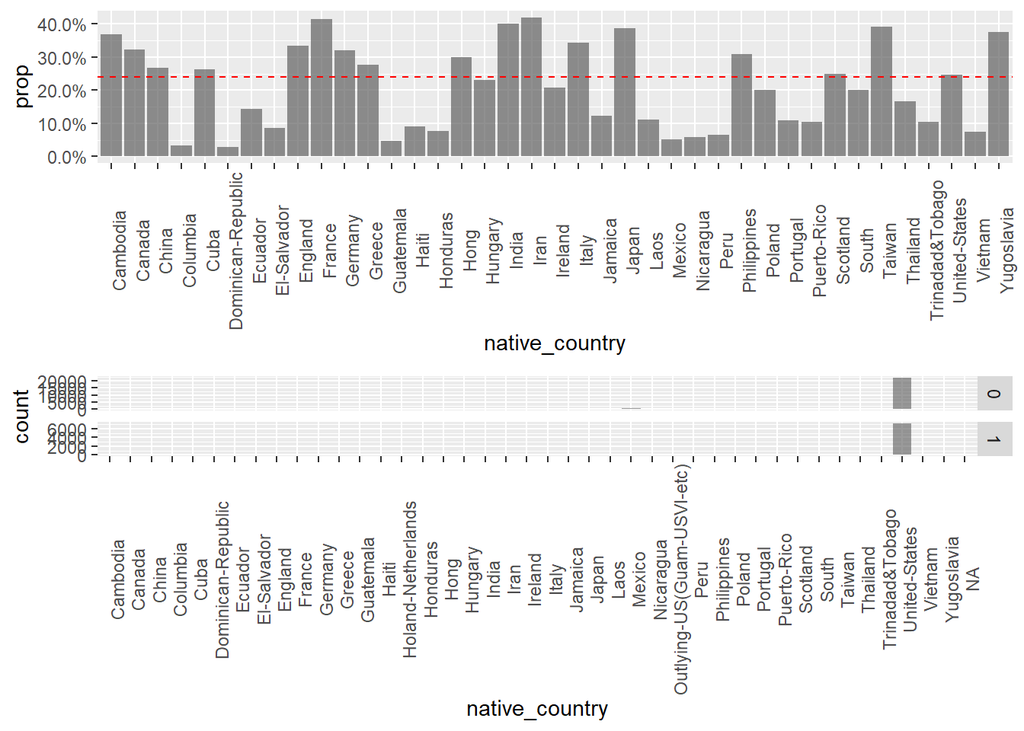

NULL

Observações:

- `education` : é possível visualizar que quanto maior o grau de escolaridade, maior a proporção de pessoas com salarios acima de 50k. E que as categorias abaixo de HS-grad, `1th-4th` até `12th`além de serem pouco representativas, possuem baixa proporção, vamos então criar uma categoria uma nova consolidando elas `HS-not-grad`.
- `marital_status` : aqui iremos agrupar os campos `Married-AF-spouse` e `Married-civ-spouse`, criando a categoria `Married`, baseado na similaridade entre elas com relação a variável resposta e considerando a descrição delas.
- `native_country` : É um campo com pouca variabilidade, onde 90% dos dados estão atribuídos como “Estados Unidos”. Sendo assim, poderia considerar apenas Estados Unidos e agrupar o restante como outros, mas vamos manter o máximo de informação e reduzir as categorias para 3, agrupando todos os países que obtiveram proporção maior que a média, manter o valor mais representativo e uma categoria com os países abaixo da média.
- `relationship` : campo contém os campos `husband` e `wife`, aparentemente poderiamos agrupa-los, vamos analisar mais afundo.
- `capital_loss` e `capital_gain` : Aparentemente tanto quem ganha quanto quem perde algum valor apresentam maiores probabilidades de ter salario >50k. Vamos então avaliar a correlação entre elas.
- `workclass` : Categorias com baixa representatividade como `Never-worked`e `Without-pay` não possuem classificação com a resposta de interesse “>50k”, vamos dar um zoom nessa variável e analisar os NA’s que identificamos também.

## 3.2 Parte 2

### 3.2.1 occupation

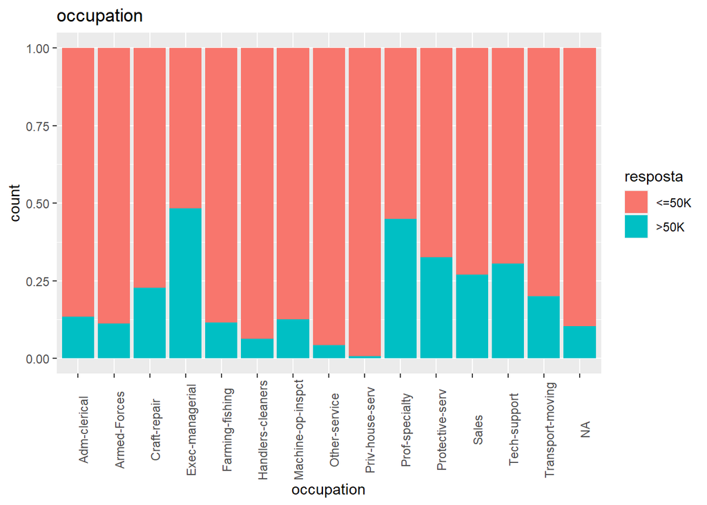

```r
ggplot(adult, aes(x = occupation, fill = resposta)) +
  geom_bar(position="fill") +
  theme(axis.text.x = element_text(angle = 90)) +
  ggtitle("occupation")
```

É possível ver que não faria sentido atribuir os NAs de forma modal, uma vez que nosso objetivo é obter o maior poder preditivo possível, logo, não queremos perder informação. Sendo assim, não vamos diluir os NAs na categoria com maior representatividade `Prof-specialty`, vamos atribuir à uma categoria com proporções similares e que possui uma boa representatividade, `Farming-fishing`.

### 3.2.2 relationship

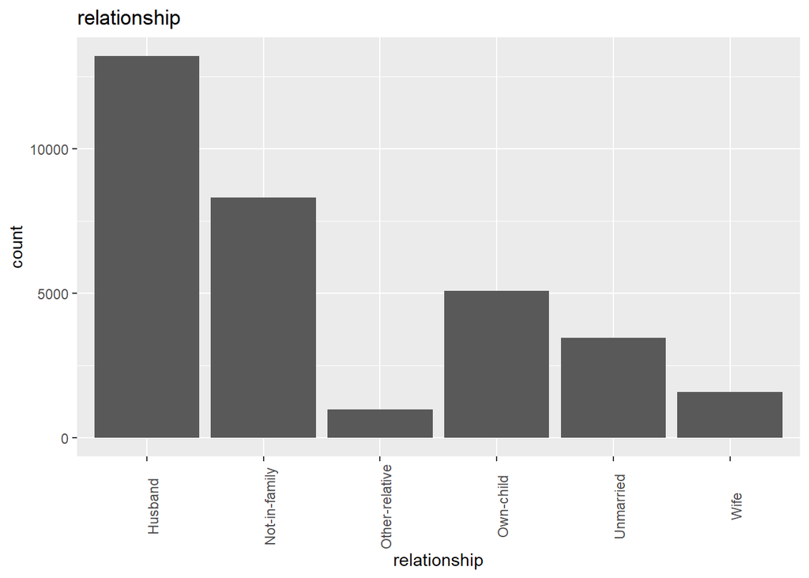

```r
ggplot(adult, aes(x = relationship)) +
  geom_bar() +
  theme(axis.text.x = element_text(angle = 90)) +
  ggtitle("relationship")
```

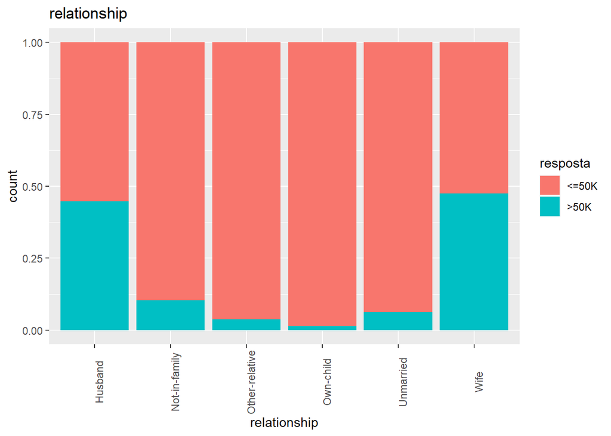

```r
ggplot(adult, aes(x = relationship, fill = resposta)) +
  geom_bar(position="fill") +
  theme(axis.text.x = element_text(angle = 90)) +
  ggtitle("relationship")
```

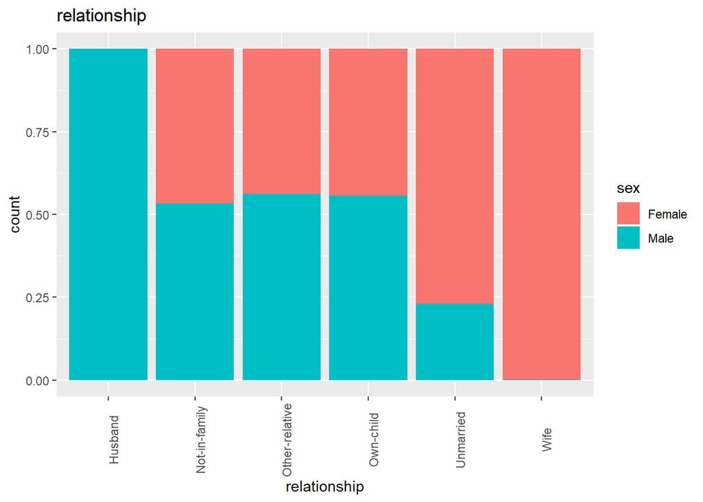

```r
ggplot(adult, aes(x = relationship, fill = sex)) +
  geom_bar(position="fill") +
  theme(axis.text.x = element_text(angle = 90)) +
  ggtitle("relationship")
```

Vamos então balancear o gênero agrupando as categorias Wife e Husband, criando a categoria `Married`.

### 3.2.3 Capital Gain and Loss

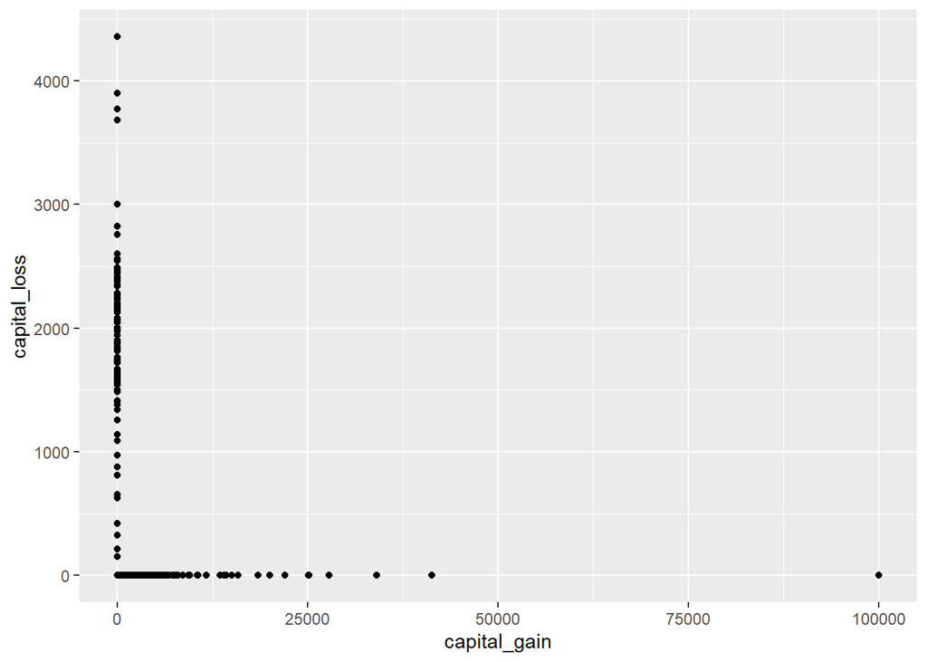

```r
ggplot(adult, aes(x= capital_gain, y= capital_loss)) +
  geom_point()
```

```r
sum(adult$capital_loss > 0 & adult$capital_gain > 0)
```

```
## [1] 0
```

Sendo assim, podemos soma-las e criar a variável `capital_total` sem medo de perder informação.

### 3.2.4 Worclass

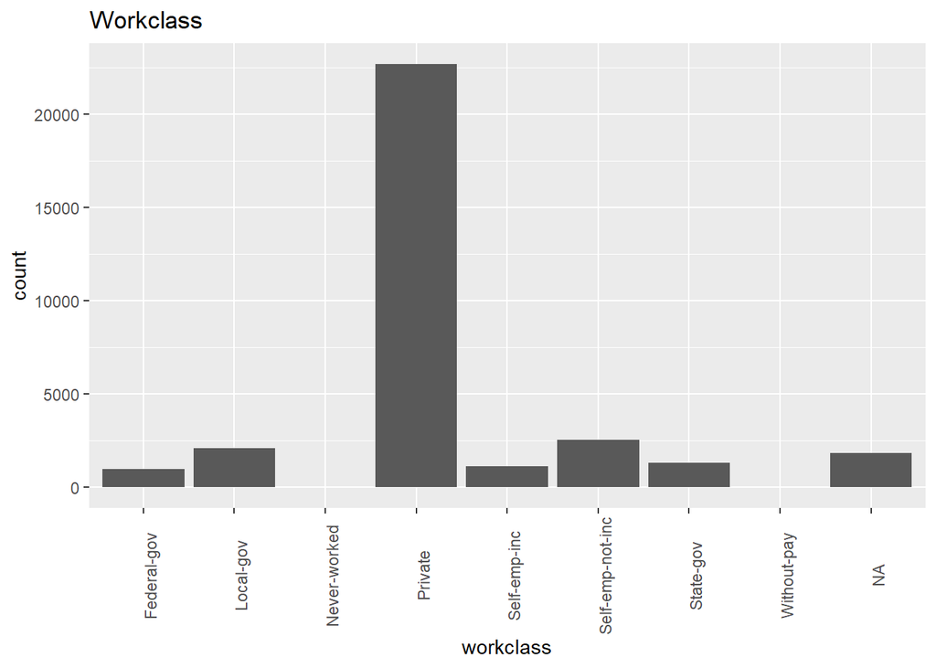

```r
ggplot(adult, aes(x = workclass)) +
  geom_bar() +
  theme(axis.text.x = element_text(angle = 90)) +
  ggtitle("Workclass")
```

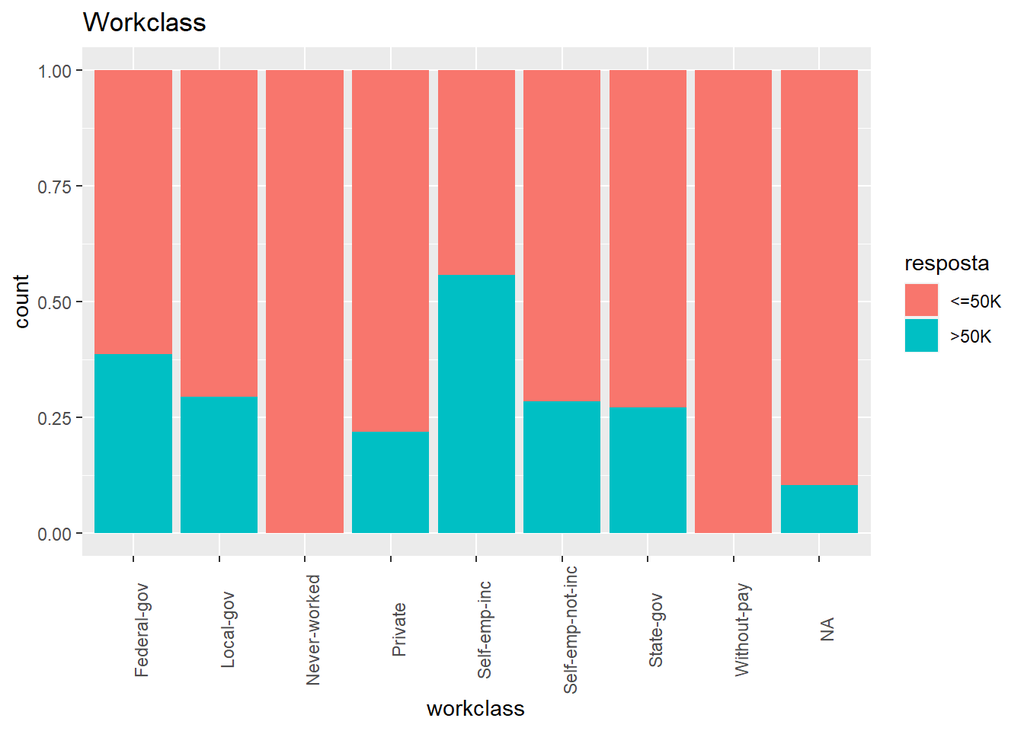

```r
ggplot(adult, aes(x = workclass, fill = resposta)) +
  geom_bar(position="fill") +
  theme(axis.text.x = element_text(angle = 90)) +
  ggtitle("Workclass")
```

Pelo visto a catgoria NA possui relação com a variável resposta distinta de todas as outras categorias, vamos então gerar uma nova categoria `not-identify` para atribuir os valores NA.

### 3.2.5 native_country

```r
med <- (adult %>%
          select(resposta) %>%
          filter(resposta == ">50K") %>%
          count() %>%
          as.numeric())/nrow(adult)


tb_country<- adult %>%
                select(native_country, resposta) %>%
                group_by(native_country) %>%
                count(resposta) %>%
                mutate(prop = prop.table(n)) %>%
                filter(resposta == ">50K") %>%
                mutate( class = case_when( native_country == "United-States" ~ "United-States",
                                           prop > med ~ ">mean",
                                           prop <= med ~ "<=mean" )  )

tb_country %>%
  select(native_country,class) %>%
  group_by(class) %>%
  count()
```

```
## # A tibble: 3 x 2
## # Groups:   class [3]
##   class             n
##   <chr>         <int>
## 1 <=mean           21
## 2 >mean            18
## 3 United-States     1
```

Ficamos então com 21 países com proporções abaixo da méda, 18 acima e “United-States” como as 3 categorias restantes.

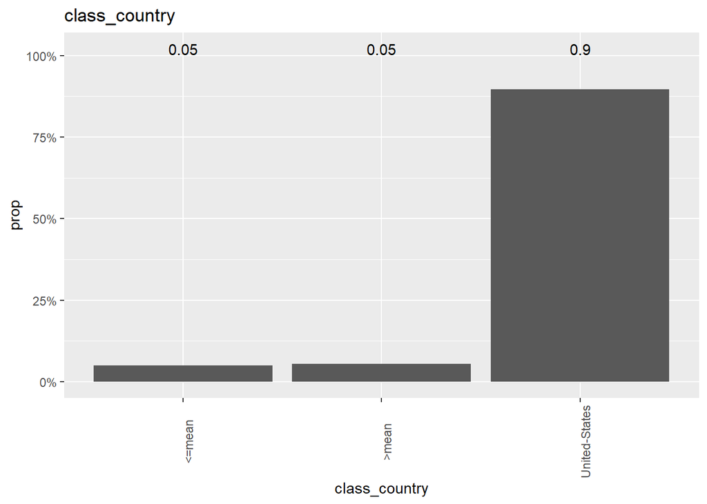

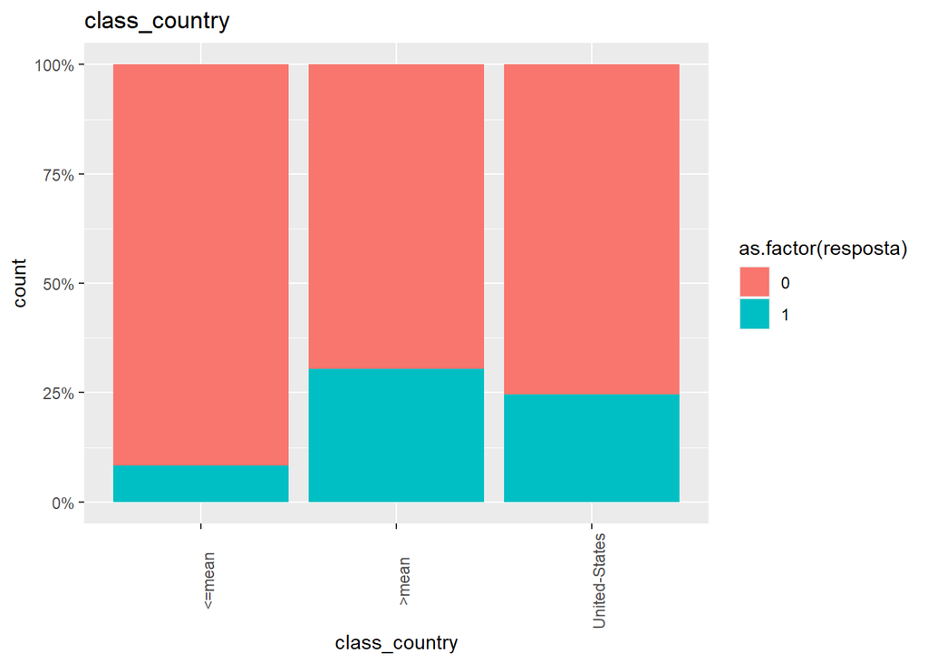

A distribuição ficou com 5% para países acima da média e 5% para países abaixo da média.

# 4 Modelagem

Com nossa a análise exploratória concluída, vamos dar início as estapas da modelagem utilizando o framework do `tidymodels`.

## 4.1 Amostragem

Fazendo a separação dos dados em treino e teste, estratificando pela variável resposta para a modelagem.

```r
set.seed(32)

adult_split <- initial_split(adult, prop = 0.8, strata = resposta)

adult_train <- training(adult_split)
adult_test <- testing(adult_split)
```

## 4.2 Data Prep

Os tratamentos necessários observados na AED, que foi feita utilizando o pacote `DataExplorer` e a função [`AED_biv`](https://github.com/ricardomattos05/functions/blob/master/function_AED_bivariada.R) que gerei para entender o comportamento das variáveis com relação a variável resposta, serão armazenados utilizando o recipes para ser utilizado tanto para treinar os modelos como para testar posteriormente.

```r
adult_recipe <-
  recipe(resposta ~ ., data = adult_train) %>%
  step_mutate(

    occupation = case_when(
      is.na(occupation) ~ "Farming-fishing",
      TRUE ~ as.character(occupation)),

    workclass = case_when(
      is.na(workclass) ~ "Not-identify",
      TRUE ~ as.character(workclass)),

    class_country = case_when(native_country %in% c("Cambodia", "Canada", "China", "Cuba", "England", "France", "Germany", "Greece", "Hong", "India", "Iran", "Italy", "Japan", "Philippines", "Scotland", "Taiwan", "Yugoslavia", NA) ~ "greater_mean",
                             native_country == "United-States" ~ "United-States",
                             TRUE ~ "smaller_mean")
    ,

    capital_total = capital_gain + capital_loss
    ,

    marital_status = case_when(
      marital_status %in% c("Married-AF-spouse" , "Married-civ-spouse") ~ "Married",
      TRUE ~ as.character(marital_status))
    ,

    education = case_when(education %in% c("1st-4th", "5th-6th", "7th-8th", "9th", "10th", "11th", "12th") ~ "HS-not-grad",
                          TRUE ~ as.character(education))
    ,

    relationship = case_when(  relationship %in% c("Husband","Wife") ~ "Married",
                               TRUE ~ as.character(relationship))

  ) %>%
  step_rm(id, capital_gain, capital_loss, native_country)%>%
  step_string2factor(all_nominal()) %>%
  step_normalize(all_numeric()) %>%
  step_zv(all_predictors()) %>%
  step_novel(all_nominal(), -all_outcomes()) %>%
  step_dummy(all_nominal(), -all_outcomes())

 # bake(prep(adult_recipe), adult_train)


adult_wf <-
  workflow() %>%
  add_recipe(adult_recipe)
```

## 4.3 Cross-Validation

Especificando a validação cruzada:

```r
set.seed(32)
adult_vfold <- vfold_cv(adult_train, v = 5, strata = resposta)
adult_vfold
```

```
## #  5-fold cross-validation using stratification
## # A tibble: 5 x 2
##   splits               id
##   <list>               <chr>
## 1 <split [20.8K/5.2K]> Fold1
## 2 <split [20.8K/5.2K]> Fold2
## 3 <split [20.8K/5.2K]> Fold3
## 4 <split [20.8K/5.2K]> Fold4
## 5 <split [20.8K/5.2K]> Fold5
```

## 4.4 Modelos

Os modelos que serão ajustados:

- Decision tree
  - Random Forest
  - Xgboost

Obs: Os valores dos hiperparâmetros foram obtidos a partir da tunagem e inseridos apenas para otimizar o tempo de renderização do script.